# hw7

Hui Sophie Wang

# 9.10

## (a)

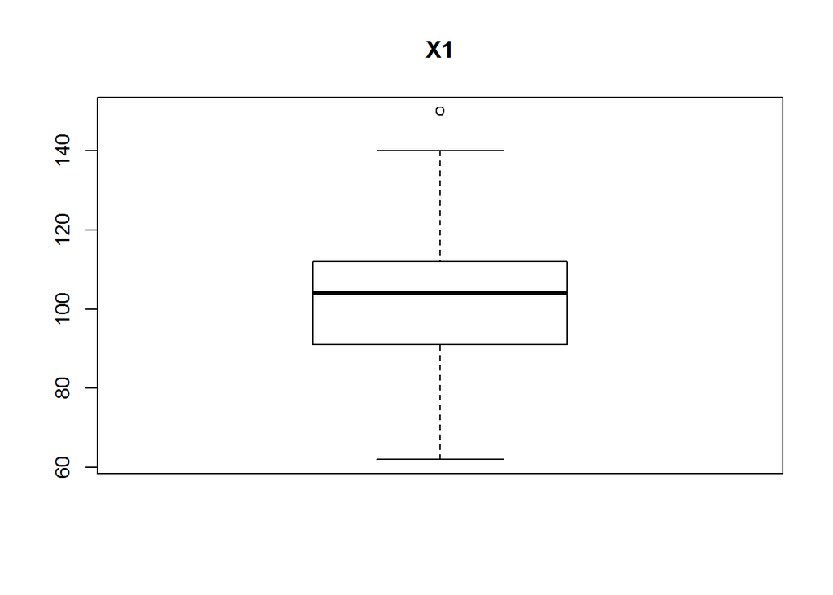

```r
scores <- read.table("https://netfiles.umn.edu/users/nacht001/www/nachtsheim/5th/KutnerData/Chapter%20%209%20Data%20Sets/CH09PR10.txt", col.names=c("Y", "X1", "X2", "X3", "X4"))
Y <- scores$Y
X1 <- scores$X1
X2 <- scores$X2
X3 <- scores$X3
X4 <- scores$X4
boxplot(X1, main="X1")
```

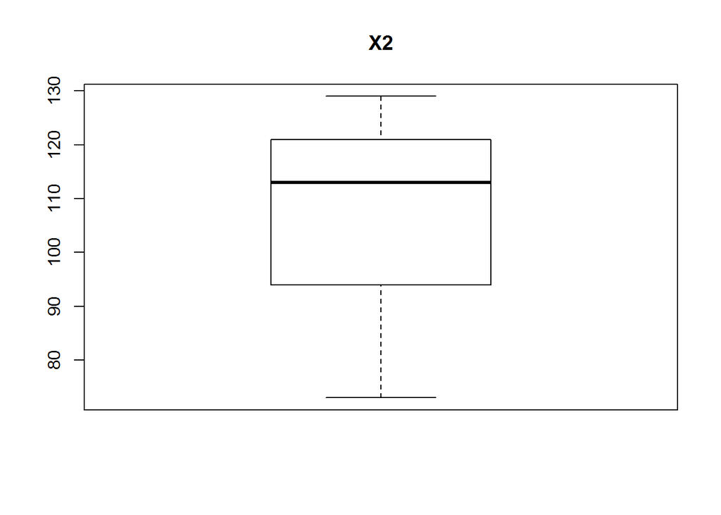

```r
boxplot(X2, main="X2")
```

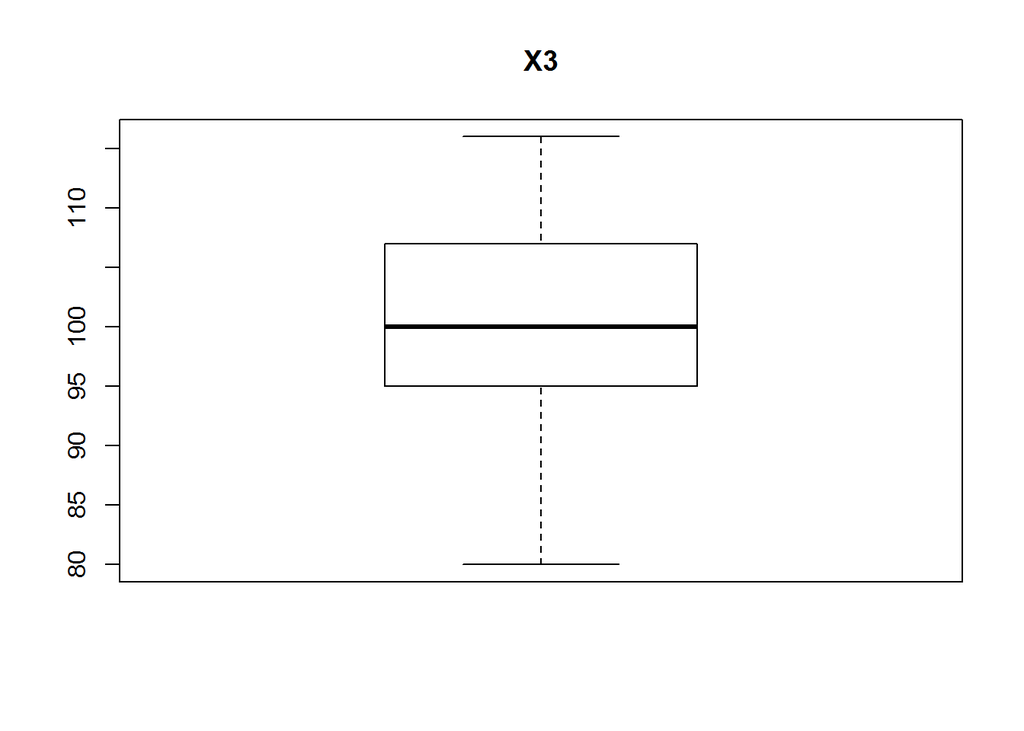

```r
boxplot(X3, main="X3")
```

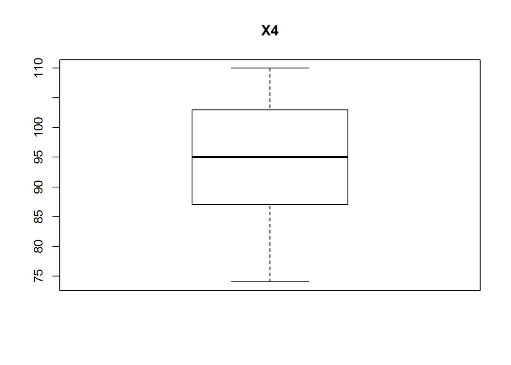

```r
boxplot(X4, main="X4")
```

There’s an outlier in X1.

X2 is skewed left.

## (b)

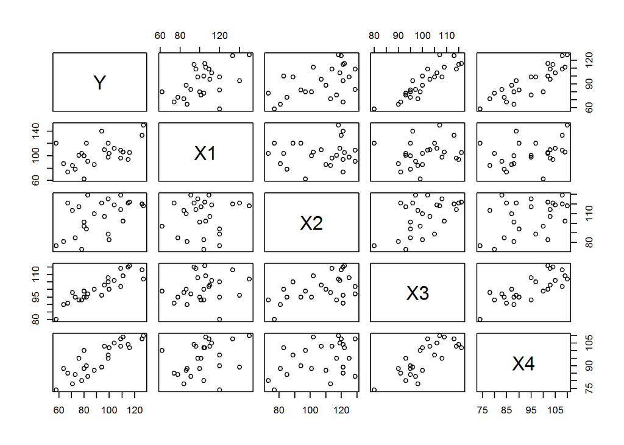

```r
pairs(scores)
```

```r
cor(scores)
```

```
##            Y        X1        X2        X3        X4
## Y  1.0000000 0.5144107 0.4970057 0.8970645 0.8693865
## X1 0.5144107 1.0000000 0.1022689 0.1807692 0.3266632
## X2 0.4970057 0.1022689 1.0000000 0.5190448 0.3967101
## X3 0.8970645 0.1807692 0.5190448 1.0000000 0.7820385
## X4 0.8693865 0.3266632 0.3967101 0.7820385 1.0000000
```

From the scatter plot matrix and the correlation matrix, we can see that Y has positive correlation with X3 and X4. There is serious multicollinearity problem, X3 and X4 are strongly correlated with each other.

## (c)

```r
fit_all <- lm(Y ~ X1 + X2 + X3 + X4)
summary(fit_all)
```

```
##
## Call:
## lm(formula = Y ~ X1 + X2 + X3 + X4)
##
## Residuals:
##     Min      1Q  Median      3Q     Max
## -5.9779 -3.4506  0.0941  2.4749  5.9959
##
## Coefficients:
##               Estimate Std. Error t value Pr(>|t|)
## (Intercept) -124.38182    9.94106 -12.512 6.48e-11 ***
## X1             0.29573    0.04397   6.725 1.52e-06 ***
## X2             0.04829    0.05662   0.853  0.40383
## X3             1.30601    0.16409   7.959 1.26e-07 ***
## X4             0.51982    0.13194   3.940  0.00081 ***
## ---
## Signif. codes:  0 '***' 0.001 '**' 0.01 '*' 0.05 '.' 0.1 ' ' 1
##
## Residual standard error: 4.099 on 20 degrees of freedom
## Multiple R-squared:  0.9629, Adjusted R-squared:  0.9555
## F-statistic: 129.7 on 4 and 20 DF,  p-value: 5.262e-14
```

The t test statistic for the coefficient of X2 is too small (its p-value is too large), it may need to be removed from the model.

# 9.11

## (a)

```r
anova(lm(Y~X1))
```

```
## Analysis of Variance Table
##
## Response: Y
##           Df Sum Sq Mean Sq F value   Pr(>F)
## X1         1 2395.9 2395.85  8.2763 0.008517 **
## Residuals 23 6658.1  289.48
## ---
## Signif. codes:  0 '***' 0.001 '**' 0.01 '*' 0.05 '.' 0.1 ' ' 1
```

```r
anova(lm(Y~X2))
```

```
## Analysis of Variance Table
##
## Response: Y
##           Df Sum Sq Mean Sq F value  Pr(>F)
## X2         1 2236.5 2236.47  7.5451 0.01149 *
## Residuals 23 6817.5  296.41
## ---
## Signif. codes:  0 '***' 0.001 '**' 0.01 '*' 0.05 '.' 0.1 ' ' 1
```

```r
anova(lm(Y~X3))
```

```
## Analysis of Variance Table
##
## Response: Y
##           Df Sum Sq Mean Sq F value    Pr(>F)
## X3         1   7286  7286.0  94.782 1.264e-09 ***
## Residuals 23   1768    76.9
## ---
## Signif. codes:  0 '***' 0.001 '**' 0.01 '*' 0.05 '.' 0.1 ' ' 1
```

```r
anova(lm(Y~X4))
```

```
## Analysis of Variance Table
##
## Response: Y
##           Df Sum Sq Mean Sq F value    Pr(>F)
## X4         1 6843.3  6843.3  71.198 1.699e-08 ***
## Residuals 23 2210.7    96.1
## ---
## Signif. codes:  0 '***' 0.001 '**' 0.01 '*' 0.05 '.' 0.1 ' ' 1
```

```r
anova(lm(Y~X1+X2))
```

```
## Analysis of Variance Table
##
## Response: Y
##           Df Sum Sq Mean Sq F value   Pr(>F)
## X1         1 2395.9 2395.85 10.8652 0.003291 **
## X2         1 1807.0 1806.97  8.1946 0.009048 **
## Residuals 22 4851.2  220.51
## ---
## Signif. codes:  0 '***' 0.001 '**' 0.01 '*' 0.05 '.' 0.1 ' ' 1
```

```r
anova(lm(Y~X1+X3))
```

```
## Analysis of Variance Table
##
## Response: Y
##           Df Sum Sq Mean Sq F value    Pr(>F)
## X1         1 2395.9  2395.9  86.884 4.269e-09 ***
## X3         1 6051.5  6051.5 219.453 6.313e-13 ***
## Residuals 22  606.7    27.6
## ---
## Signif. codes:  0 '***' 0.001 '**' 0.01 '*' 0.05 '.' 0.1 ' ' 1
```

```r
anova(lm(Y~X1+X4))
```

```
## Analysis of Variance Table
##
## Response: Y
##           Df Sum Sq Mean Sq F value    Pr(>F)
## X1         1 2395.9  2395.9  31.513 1.209e-05 ***
## X4         1 4985.6  4985.6  65.576 4.821e-08 ***
## Residuals 22 1672.6    76.0
## ---
## Signif. codes:  0 '***' 0.001 '**' 0.01 '*' 0.05 '.' 0.1 ' ' 1
```

```r
anova(lm(Y~X2+X3))
```

```
## Analysis of Variance Table
##
## Response: Y
##           Df Sum Sq Mean Sq F value    Pr(>F)
## X2         1 2236.5  2236.5  28.023 2.595e-05 ***
## X3         1 5061.7  5061.7  63.422 6.364e-08 ***
## Residuals 22 1755.8    79.8
## ---
## Signif. codes:  0 '***' 0.001 '**' 0.01 '*' 0.05 '.' 0.1 ' ' 1
```

```r
anova(lm(Y~X2+X4))
```

```
## Analysis of Variance Table
##
## Response: Y
##           Df Sum Sq Mean Sq F value    Pr(>F)
## X2         1 2236.5  2236.5  25.077 5.172e-05 ***
## X4         1 4855.5  4855.5  54.443 2.200e-07 ***
## Residuals 22 1962.1    89.2
## ---
## Signif. codes:  0 '***' 0.001 '**' 0.01 '*' 0.05 '.' 0.1 ' ' 1
```

```r
anova(lm(Y~X3+X4))
```

```
## Analysis of Variance Table
##
## Response: Y
##           Df Sum Sq Mean Sq F value    Pr(>F)
## X3         1 7286.0  7286.0 144.236 3.914e-11 ***
## X4         1  656.7   656.7  13.001   0.00157 **
## Residuals 22 1111.3    50.5
## ---
## Signif. codes:  0 '***' 0.001 '**' 0.01 '*' 0.05 '.' 0.1 ' ' 1
```

```r
anova(lm(Y~X1+X2+X3))
```

```
## Analysis of Variance Table
##
## Response: Y
##           Df Sum Sq Mean Sq F value    Pr(>F)
## X1         1 2395.9  2395.9  84.316 8.443e-09 ***
## X2         1 1807.0  1807.0  63.591 8.669e-08 ***
## X3         1 4254.5  4254.5 149.724 5.079e-11 ***
## Residuals 21  596.7    28.4
## ---
## Signif. codes:  0 '***' 0.001 '**' 0.01 '*' 0.05 '.' 0.1 ' ' 1
```

```r
anova(lm(Y~X1+X2+X4))
```

```
## Analysis of Variance Table
##
## Response: Y
##           Df Sum Sq Mean Sq F value    Pr(>F)
## X1         1 2395.9  2395.9  35.934 5.984e-06 ***
## X2         1 1807.0  1807.0  27.102 3.691e-05 ***
## X4         1 3451.1  3451.1  51.761 4.321e-07 ***
## Residuals 21 1400.1    66.7
## ---
## Signif. codes:  0 '***' 0.001 '**' 0.01 '*' 0.05 '.' 0.1 ' ' 1
```

```r
anova(lm(Y~X1+X3+X4))
```

```
## Analysis of Variance Table
##
## Response: Y
##           Df Sum Sq Mean Sq F value    Pr(>F)
## X1         1 2395.9  2395.9 144.496 7.054e-11 ***
## X3         1 6051.5  6051.5 364.969 9.359e-15 ***
## X4         1  258.5   258.5  15.588 0.0007354 ***
## Residuals 21  348.2    16.6
## ---
## Signif. codes:  0 '***' 0.001 '**' 0.01 '*' 0.05 '.' 0.1 ' ' 1
```

```r
anova(lm(Y~X2+X3+X4))
```

```
## Analysis of Variance Table
##
## Response: Y
##           Df Sum Sq Mean Sq F value    Pr(>F)
## X2         1 2236.5  2236.5  42.860 1.745e-06 ***
## X3         1 5061.7  5061.7  97.002 2.527e-09 ***
## X4         1  660.0   660.0  12.648  0.001866 **
## Residuals 21 1095.8    52.2
## ---
## Signif. codes:  0 '***' 0.001 '**' 0.01 '*' 0.05 '.' 0.1 ' ' 1
```

```r
anova(fit_all)
```

```
## Analysis of Variance Table
##
## Response: Y
##           Df Sum Sq Mean Sq F value    Pr(>F)
## X1         1 2395.9  2395.9 142.620 1.480e-10 ***
## X2         1 1807.0  1807.0 107.565 1.708e-09 ***
## X3         1 4254.5  4254.5 253.259 8.045e-13 ***
## X4         1  260.7   260.7  15.521   0.00081 ***
## Residuals 20  336.0    16.8
## ---
## Signif. codes:  0 '***' 0.001 '**' 0.01 '*' 0.05 '.' 0.1 ' ' 1
```

SSTO=9054

n=25

SSTO/(n-1)=377.25

X1: $R_{a,2}^2=1-289.48/377.25=0.2327$

X2: $R_{a,2}^2=1-296.41/377.25=0.2143$

X3: $R_{a,2}^2=1-76.9/377.25=0.7962$

X4: $R_{a,2}^2=1-96.1/377.25=0.7453$

X1,X2: $R_{a,3}^2=1-220.51/377.25=0.4155$

X1,X3: $R_{a,3}^2=1-27.6/377.25=0.9268$

X1,X4: $R_{a,3}^2=1-76/377.25=0.7985$

X2,X3: $R_{a,3}^2=1-79.8/377.25=0.7885$

X2,X4: $R_{a,3}^2=1-89.2/377.25=0.7636$

X3,X4: $R_{a,3}^2=1-50.5/377.25=0.8661$

X1,X2,X3: $R_{a,4}^2=1-28.4/377.25=0.9247$

X1,X2,X4: $R_{a,4}^2=1-66.7/377.25=0.8232$

X1,X3,X4: $R_{a,4}^2=1-16.6/377.25=0.9560$

X2,X3,X4: $R_{a,4}^2=1-52.2/377.25=0.8616$

X1,X2,X3,X4: $R_{a,5}^2=1-16.8/377.25=0.9555$

The four best subset regression models are: {X1,X3,X4} {X1,X2,X3,X4} {X1,X3} {X1,X2,X3}

## (b)

I would consider other criterias such as $C_p$, $PRESS_p$, $AIC_p$

# 9.18

## (a)

$\alpha_{enter}=0.05$

$\alpha_{remove}=0.1$

Forward Stepwise Regression:

Step 1:

```r
summary(lm(Y~X1))
```

```
##
## Call:
## lm(formula = Y ~ X1)
##
## Residuals:
##     Min      1Q  Median      3Q     Max
## -42.391 -11.670   0.531  11.842  27.407
##
## Coefficients:
##             Estimate Std. Error t value Pr(>|t|)
## (Intercept)  41.3216    18.0099   2.294  0.03123 *
## X1            0.4922     0.1711   2.877  0.00852 **
## ---
## Signif. codes:  0 '***' 0.001 '**' 0.01 '*' 0.05 '.' 0.1 ' ' 1
##
## Residual standard error: 17.01 on 23 degrees of freedom
## Multiple R-squared:  0.2646, Adjusted R-squared:  0.2326
## F-statistic: 8.276 on 1 and 23 DF,  p-value: 0.008517
```

```r
summary(lm(Y~X2))
```

```
##
## Call:
## lm(formula = Y ~ X2)
##
## Residuals:
##     Min      1Q  Median      3Q     Max
## -33.171  -9.007  -3.099  14.829  28.503
##
## Coefficients:
##             Estimate Std. Error t value Pr(>|t|)
## (Intercept)  32.6263    21.9598   1.486   0.1509
## X2            0.5582     0.2032   2.747   0.0115 *
## ---
## Signif. codes:  0 '***' 0.001 '**' 0.01 '*' 0.05 '.' 0.1 ' ' 1
##
## Residual standard error: 17.22 on 23 degrees of freedom
## Multiple R-squared:  0.247,  Adjusted R-squared:  0.2143
## F-statistic: 7.545 on 1 and 23 DF,  p-value: 0.01149
```

```r
summary(lm(Y~X3))
```

```
##
## Call:
## lm(formula = Y ~ X3)
##
## Residuals:
##      Min       1Q   Median       3Q      Max
## -15.6908  -6.1073  -0.8528   2.6658  22.6010
##
## Coefficients:
##              Estimate Std. Error t value Pr(>|t|)
## (Intercept) -106.1328    20.4472  -5.191 2.91e-05 ***
## X3             1.9676     0.2021   9.736 1.26e-09 ***
## ---
## Signif. codes:  0 '***' 0.001 '**' 0.01 '*' 0.05 '.' 0.1 ' ' 1
##
## Residual standard error: 8.768 on 23 degrees of freedom
## Multiple R-squared:  0.8047, Adjusted R-squared:  0.7962
## F-statistic: 94.78 on 1 and 23 DF,  p-value: 1.264e-09
```

```r
summary(lm(Y~X4))
```

```
##
## Call:
## lm(formula = Y ~ X4)
##
## Residuals:
##     Min      1Q  Median      3Q     Max
## -20.615  -4.268  -1.491   8.059  12.732
##
## Coefficients:
##             Estimate Std. Error t value Pr(>|t|)
## (Intercept) -57.5538    17.8558  -3.223  0.00376 **
## X4            1.5817     0.1875   8.438  1.7e-08 ***
## ---
## Signif. codes:  0 '***' 0.001 '**' 0.01 '*' 0.05 '.' 0.1 ' ' 1
##
## Residual standard error: 9.804 on 23 degrees of freedom
## Multiple R-squared:  0.7558, Adjusted R-squared:  0.7452
## F-statistic:  71.2 on 1 and 23 DF,  p-value: 1.699e-08
```

The X variable with the largest $t^*$ value is X3, its p-value is less than $\alpha_{enter}$, so X3 is added to the model.

Step 2:

```r
summary(lm(Y~X3+X1))
```

```
##
## Call:
## lm(formula = Y ~ X3 + X1)
##
## Residuals:
##     Min      1Q  Median      3Q     Max
## -9.3489 -2.8086 -0.4546  2.8981 12.6469
##
## Coefficients:
##               Estimate Std. Error t value Pr(>|t|)
## (Intercept) -127.59569   12.68526  -10.06 1.09e-09 ***
## X3             1.82321    0.12307   14.81 6.31e-13 ***
## X1             0.34846    0.05369    6.49 1.58e-06 ***
## ---
## Signif. codes:  0 '***' 0.001 '**' 0.01 '*' 0.05 '.' 0.1 ' ' 1
##
## Residual standard error: 5.251 on 22 degrees of freedom
## Multiple R-squared:  0.933,  Adjusted R-squared:  0.9269
## F-statistic: 153.2 on 2 and 22 DF,  p-value: 1.222e-13
```

```r
summary(lm(Y~X3+X2))
```

```
##
## Call:
## lm(formula = Y ~ X3 + X2)
##
## Residuals:
##      Min       1Q   Median       3Q      Max
## -16.1308  -6.2372  -0.7957   3.2946  22.3599
##
## Coefficients:
##               Estimate Std. Error t value Pr(>|t|)
## (Intercept) -106.35235   20.84198  -5.103 4.11e-05 ***
## X3             1.91868    0.24092   7.964 6.36e-08 ***
## X2             0.04826    0.12337   0.391    0.699
## ---
## Signif. codes:  0 '***' 0.001 '**' 0.01 '*' 0.05 '.' 0.1 ' ' 1
##
## Residual standard error: 8.934 on 22 degrees of freedom
## Multiple R-squared:  0.8061, Adjusted R-squared:  0.7884
## F-statistic: 45.72 on 2 and 22 DF,  p-value: 1.459e-08
```

```r
summary(lm(Y~X3+X4))
```

```
##
## Call:
## lm(formula = Y ~ X3 + X4)
##
## Residuals:
##      Min       1Q   Median       3Q      Max
## -14.1751  -4.6526  -0.5954   4.6428  15.1523
##
## Coefficients:
##              Estimate Std. Error t value Pr(>|t|)
## (Intercept) -105.8522    16.5754  -6.386    2e-06 ***
## X3             1.2264     0.2629   4.665 0.000119 ***
## X4             0.7862     0.2180   3.606 0.001570 **
## ---
## Signif. codes:  0 '***' 0.001 '**' 0.01 '*' 0.05 '.' 0.1 ' ' 1
##
## Residual standard error: 7.107 on 22 degrees of freedom
## Multiple R-squared:  0.8773, Adjusted R-squared:  0.8661
## F-statistic: 78.62 on 2 and 22 DF,  p-value: 9.527e-11
```

Considering two X variables, where X3 is one of the pair, (X3,X1) has the largest $t^*$ value, and its p-value is less than $\alpha_{enter}$, so X1 is added to the model. We don’t need to test whether X3 is needed to be dropped, because in step 1 we already covered this case.

Step 3:

```r
summary(lm(Y~X3+X1+X2))
```

```
##
## Call:
## lm(formula = Y ~ X3 + X1 + X2)
##
## Residuals:
##     Min      1Q  Median      3Q     Max
## -9.7517 -3.0371 -0.4618  1.8358 11.7315
##
## Coefficients:
##               Estimate Std. Error t value Pr(>|t|)
## (Intercept) -127.77378   12.88053  -9.920 2.23e-09 ***
## X3             1.77921    0.14541  12.236 5.08e-11 ***
## X1             0.34813    0.05451   6.387 2.48e-06 ***
## X2             0.04353    0.07362   0.591    0.561
## ---
## Signif. codes:  0 '***' 0.001 '**' 0.01 '*' 0.05 '.' 0.1 ' ' 1
##
## Residual standard error: 5.331 on 21 degrees of freedom
## Multiple R-squared:  0.9341, Adjusted R-squared:  0.9247
## F-statistic: 99.21 on 3 and 21 DF,  p-value: 1.457e-12
```

```r
summary(lm(Y~X3+X1+X4))
```

```
##
## Call:
## lm(formula = Y ~ X3 + X1 + X4)
##
## Residuals:
##     Min      1Q  Median      3Q     Max
## -5.4579 -3.1563 -0.2057  1.8070  6.6083
##
## Coefficients:
##               Estimate Std. Error t value Pr(>|t|)
## (Intercept) -124.20002    9.87406 -12.578 3.04e-11 ***
## X3             1.35697    0.15183   8.937 1.33e-08 ***
## X1             0.29633    0.04368   6.784 1.04e-06 ***
## X4             0.51742    0.13105   3.948 0.000735 ***
## ---
## Signif. codes:  0 '***' 0.001 '**' 0.01 '*' 0.05 '.' 0.1 ' ' 1
##
## Residual standard error: 4.072 on 21 degrees of freedom
## Multiple R-squared:  0.9615, Adjusted R-squared:  0.956
## F-statistic:   175 on 3 and 21 DF,  p-value: 5.16e-15
```

```r
summary(lm(Y~X1))
```

```
##
## Call:
## lm(formula = Y ~ X1)
##
## Residuals:
##     Min      1Q  Median      3Q     Max
## -42.391 -11.670   0.531  11.842  27.407
##
## Coefficients:
##             Estimate Std. Error t value Pr(>|t|)
## (Intercept)  41.3216    18.0099   2.294  0.03123 *
## X1            0.4922     0.1711   2.877  0.00852 **
## ---
## Signif. codes:  0 '***' 0.001 '**' 0.01 '*' 0.05 '.' 0.1 ' ' 1
##
## Residual standard error: 17.01 on 23 degrees of freedom
## Multiple R-squared:  0.2646, Adjusted R-squared:  0.2326
## F-statistic: 8.276 on 1 and 23 DF,  p-value: 0.008517
```

Step 4:

```r
summary(lm(Y~X3+X1+X4+X2))
```

```
##
## Call:
## lm(formula = Y ~ X3 + X1 + X4 + X2)
##
## Residuals:
##     Min      1Q  Median      3Q     Max
## -5.9779 -3.4506  0.0941  2.4749  5.9959
##
## Coefficients:
##               Estimate Std. Error t value Pr(>|t|)
## (Intercept) -124.38182    9.94106 -12.512 6.48e-11 ***
## X3             1.30601    0.16409   7.959 1.26e-07 ***
## X1             0.29573    0.04397   6.725 1.52e-06 ***
## X4             0.51982    0.13194   3.940  0.00081 ***
## X2             0.04829    0.05662   0.853  0.40383
## ---
## Signif. codes:  0 '***' 0.001 '**' 0.01 '*' 0.05 '.' 0.1 ' ' 1
##
## Residual standard error: 4.099 on 20 degrees of freedom
## Multiple R-squared:  0.9629, Adjusted R-squared:  0.9555
## F-statistic: 129.7 on 4 and 20 DF,  p-value: 5.262e-14
```

We consider all the four X variables at this step. When the last variable X2 is added, its p-value is larger than $\alpha_{enter}$, so it should not be added.

The best subset found is {X1,X3,X4}

## (b)

The best subset found by forward stepwise regression is also the best subset found by $R_{a,p}^2$

# 9.21

```r
# method 1: (fit the model n times)
n <- length(Y)
X <- cbind(X1, X3, X4)
total <- 0
for(i in 1:n){
  fit <- lm(Y[-i]~X[-i,])
  d <- Y[i] - (X[i,] %*% fit$coefficients[2:4] + fit$coefficients[1])
  total <- total + d^2
}
total
```

```
##         [,1]
## [1,] 471.452
```

```r
# method 2: (fit the model 1 time, and use equation 10.21a)
X <- cbind(1, X1, X3, X4)
H <- X %*% solve(t(X)%*%X) %*% t(X)
e <- (diag(n)-H) %*% Y
d <- e / (1-diag(H))
sum(d^2)
```

```
## [1] 471.452
```

```r
fit_best <- lm(Y~X1+X3+X4)
summary(fit_best)
```

```
##
## Call:
## lm(formula = Y ~ X1 + X3 + X4)
##
## Residuals:
##     Min      1Q  Median      3Q     Max
## -5.4579 -3.1563 -0.2057  1.8070  6.6083
##
## Coefficients:
##               Estimate Std. Error t value Pr(>|t|)
## (Intercept) -124.20002    9.87406 -12.578 3.04e-11 ***
## X1             0.29633    0.04368   6.784 1.04e-06 ***
## X3             1.35697    0.15183   8.937 1.33e-08 ***
## X4             0.51742    0.13105   3.948 0.000735 ***
## ---
## Signif. codes:  0 '***' 0.001 '**' 0.01 '*' 0.05 '.' 0.1 ' ' 1
##
## Residual standard error: 4.072 on 21 degrees of freedom
## Multiple R-squared:  0.9615, Adjusted R-squared:  0.956
## F-statistic:   175 on 3 and 21 DF,  p-value: 5.16e-15
```

```r
anova(fit_best)
```

```
## Analysis of Variance Table
##
## Response: Y
##           Df Sum Sq Mean Sq F value    Pr(>F)
## X1         1 2395.9  2395.9 144.496 7.054e-11 ***
## X3         1 6051.5  6051.5 364.969 9.359e-15 ***
## X4         1  258.5   258.5  15.588 0.0007354 ***
## Residuals 21  348.2    16.6
## ---
## Signif. codes:  0 '***' 0.001 '**' 0.01 '*' 0.05 '.' 0.1 ' ' 1
```

PRESS=471.45, SSE=348.2, SSE is smaller than PRESS, but is close to it, which means SSE is a reasonably valid indicator of the predicative ability of the fitted model.

# 9.22

## (a)

```r
vali <- read.table("https://netfiles.umn.edu/users/nacht001/www/nachtsheim/5th/KutnerData/Chapter%20%209%20Data%20Sets/CH09PR22.txt", col.names=c("Y", "X1", "X2", "X3", "X4"))

cor(vali)
```

```
##            Y         X1         X2        X3        X4
## Y  1.0000000 0.53707787 0.34477442 0.8880519 0.8879388
## X1 0.5370779 1.00000000 0.01057088 0.1772891 0.3196395
## X2 0.3447744 0.01057088 1.00000000 0.3437441 0.2207638
## X3 0.8880519 0.17728907 0.34374413 1.0000000 0.8714466
## X4 0.8879388 0.31963945 0.22076377 0.8714466 1.0000000
```

The correlatioin matrix of the validation data set is reasonably close to that of the model-building data set.

## (b)

```r
Y_vali <- vali$Y
X1_vali <- vali$X1
X2_vali <- vali$X2
X3_vali <- vali$X3
X4_vali <- vali$X4
fit_vali <- lm(Y_vali~X1_vali+X3_vali+X4_vali)
summary(fit_vali)
```

```
##
## Call:
## lm(formula = Y_vali ~ X1_vali + X3_vali + X4_vali)
##
## Residuals:
##     Min      1Q  Median      3Q     Max
## -9.4619 -2.3836  0.6834  2.1123  7.2394
##
## Coefficients:
##               Estimate Std. Error t value Pr(>|t|)
## (Intercept) -122.76705   11.84783 -10.362 1.04e-09 ***
## X1_vali        0.31238    0.04729   6.605 1.54e-06 ***
## X3_vali        1.40676    0.23262   6.048 5.31e-06 ***
## X4_vali        0.42838    0.19749   2.169   0.0417 *
## ---
## Signif. codes:  0 '***' 0.001 '**' 0.01 '*' 0.05 '.' 0.1 ' ' 1
##
## Residual standard error: 4.284 on 21 degrees of freedom
## Multiple R-squared:  0.9489, Adjusted R-squared:  0.9416
## F-statistic:   130 on 3 and 21 DF,  p-value: 1.017e-13
```

```r
anova(fit_vali)
```

```
## Analysis of Variance Table
##
## Response: Y_vali
##           Df Sum Sq Mean Sq  F value    Pr(>F)
## X1_vali    1 2175.3  2175.3 118.5145 4.291e-10 ***
## X3_vali    1 4894.2  4894.2 266.6434 2.070e-13 ***
## X4_vali    1   86.4    86.4   4.7049    0.0417 *
## Residuals 21  385.5    18.4
## ---
## Signif. codes:  0 '***' 0.001 '**' 0.01 '*' 0.05 '.' 0.1 ' ' 1
```

|  | training set | validation set |
| --- | --- | --- |
| b0 | -124.2 | -122.77 |
| s{b0} | 9.874 | 11.848 |
| b1 | 0.296 | 0.312 |
| s{b1} | 0.044 | 0.047 |
| b3 | 1.357 | 1.407 |
| s{b3} | 0.152 | 0.233 |
| b4 | 0.517 | 0.428 |
| s{b4} | 0.131 | 0.197 |
| MSE | 16.6 | 18.4 |
| $R^2$ | 0.9616 | 0.9489 |

The estimates for the validation data set appear to be resonably similar to those obtained for the training set.

## (c)

```r
X_vali <- cbind(1, X1_vali, X3_vali, X4_vali)
b_train <- fit_best$coefficients
Y_hat <- X_vali %*% b_train
n_vali <- length(Y_vali)
sum((Y_vali-Y_hat)^2)/n_vali
```

```
## [1] 15.70972
```

MSPR = 15.71, MSE obtained from training set is 16.6, there isn’t evidence of a substantial bias problem in MSE here. It is consistent with the finding in Problem 9.21 that MSE is a reasonably valid indicator of the predictability of the model.

## (d)

```r
Y <- append(Y, Y_vali)
X1 <- append(X1, X1_vali)
X2 <- append(X2, X2_vali)
X3 <- append(X3, X3_vali)
X4 <- append(X4, X4_vali)
fit <- lm(Y~X1+X3+X4)
summary(fit)
```

```
##
## Call:
## lm(formula = Y ~ X1 + X3 + X4)
##
## Residuals:
##     Min      1Q  Median      3Q     Max
## -9.7192 -2.7369  0.1278  2.0971  7.0657
##
## Coefficients:
##               Estimate Std. Error t value Pr(>|t|)
## (Intercept) -123.44104    7.16508 -17.228  < 2e-16 ***
## X1             0.30364    0.03072   9.886 5.86e-13 ***
## X3             1.36906    0.12280  11.148 1.15e-14 ***
## X4             0.48735    0.10475   4.652 2.79e-05 ***
## ---
## Signif. codes:  0 '***' 0.001 '**' 0.01 '*' 0.05 '.' 0.1 ' ' 1
##
## Residual standard error: 4.006 on 46 degrees of freedom
## Multiple R-squared:  0.9567, Adjusted R-squared:  0.9539
## F-statistic: 338.9 on 3 and 46 DF,  p-value: < 2.2e-16
```

The estimated standard deviations of the coefficients of the combined data are reduced from those obtained for the training data.

# 14.2

No, it can’t be used as in linear regression. Because it violates the assumptions of linear regression. Y is not normally distributed, and its variance is not constant.

# 14.14

## (a)

```r
data <- read.table("https://netfiles.umn.edu/users/nacht001/www/nachtsheim/5th/KutnerData/Chapter%2014%20Data%20Sets/CH14PR14.txt", col.names=c("Y", "X1", "X2", "X3"))
Y <- data$Y
X1 <- data$X1
X2 <- data$X2
X3 <- data$X3
logit <- glm(Y~X1+X2+X3, family=binomial)
summary(logit)
```

```
##
## Call:
## glm(formula = Y ~ X1 + X2 + X3, family = binomial)
##
## Deviance Residuals:
##     Min       1Q   Median       3Q      Max
## -1.4037  -0.5637  -0.3352  -0.1542   2.9394
##
## Coefficients:
##             Estimate Std. Error z value Pr(>|z|)
## (Intercept) -1.17716    2.98242  -0.395  0.69307
## X1           0.07279    0.03038   2.396  0.01658 *
## X2          -0.09899    0.03348  -2.957  0.00311 **
## X3           0.43397    0.52179   0.832  0.40558
## ---
## Signif. codes:  0 '***' 0.001 '**' 0.01 '*' 0.05 '.' 0.1 ' ' 1
##
## (Dispersion parameter for binomial family taken to be 1)
##
##     Null deviance: 134.94  on 158  degrees of freedom
## Residual deviance: 105.09  on 155  degrees of freedom
## AIC: 113.09
##
## Number of Fisher Scoring iterations: 6
```

b0 = -1.177

b1 = 0.073

b2 = -0.099

b3 = 0.434

$Y_i\sim{Bernoulli(\pi_i)}$ where $\hat{\pi_i}=\frac{exp(-1.177+0.073X_1-0.099X_2+0.434X_3)}{1+exp(-1.177+0.073X_1-0.099X_2+0.434X_3)}$

## (b)

```r
exp(coef(logit))
```

```
## (Intercept)          X1          X2          X3
##   0.3081529   1.0755025   0.9057549   1.5433801
```

exp(b1) = 1.076

Interpretation: The odds of receiving the flu shot increases by 7.6 percent when age increases by 1 year, while health awareness and gender are hold constant.

exp(b2) = 0.906

Interpretation: The odds of receiving the flu shot decreases by 9.4 percent when health awareness increases by 1 unit, while age and gender are hold constant.

exp(b3) = 1.543

Interpretation: The odds of receiving the flu shot increases by 54.3 percent when the gender is male instead of female, while age and health awareness are hold constant.

## (c)

```r
pi_prime <- sum(coef(logit)*c(1,55,60,1))
pi <- exp(pi_prime)/(1+exp(pi_prime))
pi
```

```
## [1] 0.06422197
```

When X1=55, X2=60, X3=1, the estimated probability $\hat{\pi_i}=0.064$